# Intro to Linear Regression

## BogaziciAI

Linear regression is the process of modelling a linear relationship between variables.

In order to understand it clearly, we can define a custom dataset, that includes a linear relationship between 2 variables. Let's assume that our dataset is linearly correlated as Y=AX+B ideally.

```python
import warnings
warnings.filterwarnings('ignore')
```

```python
import numpy as np
import matplotlib.pyplot as plt
from sklearn import linear_model
```

First create a dataset that has disturbances.

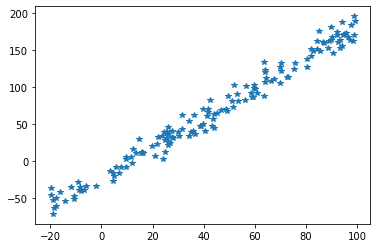

```python
A = 2
B = -20
x_range = [-20, 100]

def load_dataset(n=150):
  x = (x_range[1] - x_range[0]) * np.random.rand(n) + x_range[0]
  eps = np.random.normal(0,10,n)
  y = A * x  + B + eps
  return np.array(y).reshape(-1,1), np.array(x).reshape(-1,1)

y, x = load_dataset()

plt.plot(x,y,'*')
plt.show()
```

As data seem to be correlated linearly, (We already know that in this situation as it is created by us, but we need to inspect unkown datasets in order to choose an eligable method.) it is appropriate to apply linear regression.

```
A: 2.01		B: -20.94	R2: 0.979
```

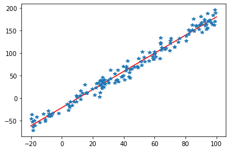

```python
regression = linear_model.LinearRegression()
regression = regression.fit(x,y)
print(f"A: {regression.coef_[0][0]:.2f}\t\tB: {regression.intercept_[0]:.2f}\tR2: {regression.score(x,y):.3f}")

x_pred = np.array(x_range).reshape(-1,1)
y_pred = regression.predict(x_pred)
plt.plot(x_pred,y_pred,'r-',x,y,'*')
plt.show()
```

# Load CVS file with PANDAS

In this section, you are given weather data. You will use pandas dataframe to load csv file. Observe dataframe shape and by using .head(), investigate the content of the data.

```python
import pandas as pd
WeatherData=pd.read_csv('weatherHistory.csv')
WeatherData.shape
```

```
(1999, 12)
```

```python
WeatherData.head()
```

|  | Formatted Date | Summary | Precip Type | Temperature | Apparent Temperature | Humidity | Wind Speed | Wind Bearing | Visibility | Loud Cover | Pressure | Daily Summary |
| --- | --- | --- | --- | --- | --- | --- | --- | --- | --- | --- | --- | --- |
| 0 | 2006-04-01 00:00:00.000 +0200 | Partly Cloudy | rain | 9.472222 | 7.388889 | 0.89 | 14.1197 | 251 | 15.8263 | 0 | 1015.13 | Partly cloudy throughout the day. |
| 1 | 2006-04-01 01:00:00.000 +0200 | Partly Cloudy | rain | 9.355556 | 7.227778 | 0.86 | 14.2646 | 259 | 15.8263 | 0 | 1015.63 | Partly cloudy throughout the day. |
| 2 | 2006-04-01 02:00:00.000 +0200 | Mostly Cloudy | rain | 9.377778 | 9.377778 | 0.89 | 3.9284 | 204 | 14.9569 | 0 | 1015.94 | Partly cloudy throughout the day. |
| 3 | 2006-04-01 03:00:00.000 +0200 | Partly Cloudy | rain | 8.288889 | 5.944444 | 0.83 | 14.1036 | 269 | 15.8263 | 0 | 1016.41 | Partly cloudy throughout the day. |
| 4 | 2006-04-01 04:00:00.000 +0200 | Mostly Cloudy | rain | 8.755556 | 6.977778 | 0.83 | 11.0446 | 259 | 15.8263 | 0 | 1016.51 | Partly cloudy throughout the day. |

```python
WeatherData.info()
```

```
<class 'pandas.core.frame.DataFrame'>
RangeIndex: 1999 entries, 0 to 1998
Data columns (total 12 columns):
 #   Column                Non-Null Count  Dtype
---  ------                --------------  -----
 0   Formatted Date        1999 non-null   object
 1   Summary               1999 non-null   object
 2   Precip Type           1999 non-null   object
 3   Temperature           1999 non-null   float64
 4   Apparent Temperature  1999 non-null   float64
 5   Humidity              1999 non-null   float64
 6   Wind Speed            1999 non-null   float64
 7   Wind Bearing          1999 non-null   int64
 8   Visibility            1999 non-null   float64
 9   Loud Cover            1999 non-null   int64
 10  Pressure              1999 non-null   float64
 11  Daily Summary         1999 non-null   object
dtypes: float64(6), int64(2), object(4)
memory usage: 187.5+ KB
```

```python
Temp=WeatherData.Temperature
Hum=WeatherData.Humidity
type(Temp)
type(Hum)
```

```
pandas.core.series.Series
```

Data visualization is cruicial to understand the quality of the data. You need to observe inputs and outputs to form a hypothesis about possible correlations. Investigate matplotlib.

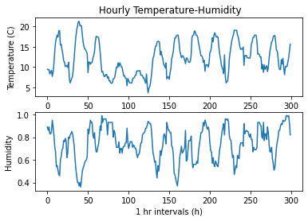

```python
import matplotlib.pyplot as plt


fig = plt.figure()
ax1 = fig.add_subplot(2, 1, 1) # two rows, one column, first plot
ax1.set_ylabel('Temperature (C)')
ax1.set_xlabel('1 hr intervals (h)')
ax1.set_title(' Hourly Temperature-Humidity')
ax1.plot(Temp[0:300])

ax2 = fig.add_subplot(2, 1, 2) # two rows, one column, first plot
ax2.set_ylabel('Humidity ')
ax2.set_xlabel('1 hr intervals (h)')
ax2.plot(Hum[0:300])
```

Lets scatterplot the same data to see different kinds of visualizations.

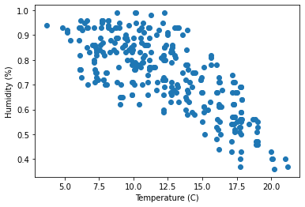

```python
fig = plt.figure()
plt.scatter(Temp[0:300],Hum[0:300])
plt.xlabel('Temperature (C)')
plt.ylabel('Humidity (%)')
```

Optional Exercise : Use .scatter(Temp[0:300], WindSpeed[0:300], Hum[0:300]) to make a 3d plot including windspeed for the first 300 data points.

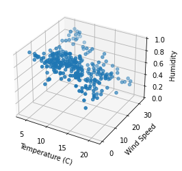

```python
#ax = plt.figure().add_subplot(projection='3d')
ax = plt.figure().add_subplot(projection='3d')
#ax.
WindSpeed = WeatherData['Wind Speed']
ax.scatter(Temp[0:300], WindSpeed[0:300], Hum[0:300])
ax.set_zlim(0,1)
#ax.set_zlim(0, 1)
ax.set_xlabel('Temperature (C)')
ax.set_ylabel('Wind Speed')
ax.set_zlabel('Humidity')
#ax.set_xlabel('Temperature (C)')
#ax.set_ylabel('Wind Speed')
#ax.set_zlabel('Humidity')
```

# Real Estate Data, Linear and Nonlinear Regression

```python
import pandas as pd
import matplotlib.pyplot as plt
#################  Dosya ismi Realestate.csv, panda dataframe olarak yukleyin
HouseData= pd.read_csv(r"C:\Users\fatma\Desktop\Realestate.csv")
#################
HouseData.shape
```

```
(428, 8)
```

```python
HouseData.info()
```

```
<class 'pandas.core.frame.DataFrame'>
RangeIndex: 428 entries, 0 to 427
Data columns (total 8 columns):
 #   Column                Non-Null Count  Dtype
---  ------                --------------  -----
 0   No                    428 non-null    int64
 1   transactiondate       428 non-null    float64
 2   houseage              428 non-null    float64
 3   distancetostation     428 non-null    float64
 4   numberofstores        428 non-null    int64
 5   latitude              428 non-null    float64
 6   longitude             428 non-null    float64
 7   housepriceofunitarea  428 non-null    float64
dtypes: float64(6), int64(2)
memory usage: 26.9 KB
```

```python
HouseData.head()
```

|  | No | transactiondate | houseage | distancetostation | numberofstores | latitude | longitude | housepriceofunitarea |
| --- | --- | --- | --- | --- | --- | --- | --- | --- |
| 0 | 0 | 2012.1 | 15.0 | 88.0 | 3 | 1.0 | 2.0 | 195.4 |
| 1 | 0 | 2012.1 | 12.0 | 300.0 | 3 | 1.0 | 2.0 | 85.7 |
| 2 | 0 | 2012.1 | 14.0 | 658.0 | 5 | 1.0 | 2.0 | 44.9 |
| 3 | 0 | 2012.1 | 20.0 | 204.0 | 7 | 1.0 | 2.0 | 135.6 |
| 4 | 0 | 2012.1 | 22.0 | 1020.0 | 6 | 1.0 | 2.0 | 33.5 |

# Linear Regression

Example: run the code in 3 sections in order for ToNthHouse=10 and ToNthHouse=14 and answer 3 questions below

```
(0.0, 220.0)
```

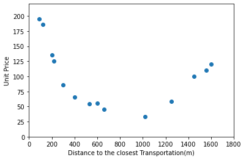

```python
import pandas as pd

Dist=HouseData['distancetostation'].to_numpy()
Price=HouseData['housepriceofunitarea'].to_numpy()
Age=HouseData['houseage'].to_numpy()

######  First Examine House Distance vs Price for the first 10 house values(ToNthHouse) then 14

ToNthHouse=14

######
fig = plt.figure()
plt.scatter(Dist[:ToNthHouse],Price[:ToNthHouse])
plt.xlabel('Distance to the closest Transportation(m)')
plt.ylabel('Unit Price')
plt.xlim(0,1800)
plt.ylim(0,220)
```

```python
from sklearn.linear_model import LinearRegression
reg = LinearRegression()
reg.fit(Dist[:ToNthHouse].reshape(-1, 1), Price[:ToNthHouse].reshape(-1, 1))
reg.score(Dist[:ToNthHouse].reshape(-1, 1), Price[:ToNthHouse].reshape(-1, 1))
```

```
0.11621887832556999
```

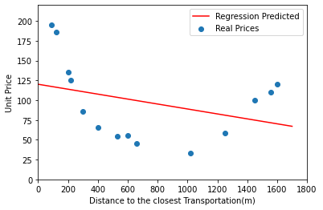

```python
import numpy as np
PredictedPrice=reg.predict(np.arange(0,1800,100).reshape(-1,1))

fig = plt.figure()
plt.scatter(Dist[:ToNthHouse],Price[:ToNthHouse])
plt.xlabel('Distance to the closest Transportation(m)')
plt.ylabel('Unit Price')
plt.xlim(0,1800)
plt.ylim(0,220)
plt.plot(np.arange(0,1800,100),PredictedPrice,'r')
plt.legend(['Regression Predicted','Real Prices'])
```

QUESTIONS:

1) What is the regression score (reg.score, out[177]) for ToNthHouse= 10 and 14. Write your answers below.

2) Outliers in regression are observations that fall far from the “cloud” of points. These points might be especially important. Which ones would be the outlier in ToNthHouse=10 and ToNthHouse=14 cases?

3) Why do you think that regression score differs so much when 4 additional data points are added? Hint: print Panda dataframe information for indices 0-14 (HouseData[0:14]) . Do you think that linear regression Y=aX+B is useful in this case?

1. 0.752143701166438, 0.11621887832556999
2. For ToNthHouse=10; there are 3 point far away from the predicted line but I dont call them outliers. For ToNthHouse=14; the line is not fitting the real values and for that line, I can call all the points as an outlier.
3. Because, as the distance of the closest transportaion increased, in contrast to what we expect and the linear regression predicts, the unit price of the house is not decreasing. Thus, y = ax+b is not useful.

# Nonlinear Nth Degree poly. Regression, Y=aX^(n)+bX^(n-1)...+gX^1+h

#### Example: Command N_poly_degree, change the polynomial nonlinear regression degree and observe how the scores of the predictions change

```python
from sklearn.preprocessing import PolynomialFeatures
ToNthHouse=14
N_poly_degree=2
####
#N_poly_degree=2
####
poly = PolynomialFeatures(N_poly_degree)
Dist_transformed=poly.fit_transform(Dist[:ToNthHouse].reshape(-1,1))

model = LinearRegression()

model.fit(Dist_transformed,Price[:ToNthHouse].reshape(-1, 1) )
model.score(Dist_transformed,Price[:ToNthHouse].reshape(-1, 1))
```

```
0.9358567701993217
```

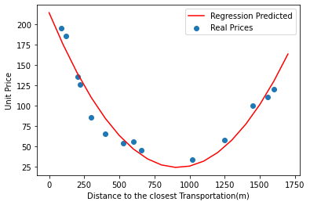

```python
Dist_Prediction_transformed=poly.fit_transform(np.arange(0,1800,100).reshape(-1,1))
PredictedPrice=model.predict(Dist_Prediction_transformed)

fig = plt.figure()
plt.scatter(Dist[:ToNthHouse],Price[:ToNthHouse])
plt.xlabel('Distance to the closest Transportation(m)')
plt.ylabel('Unit Price')

plt.plot(np.arange(0,1800,100),PredictedPrice,'r')
plt.legend(['Regression Predicted','Real Prices'])
```

Question: When we switched to nonlinear regression, the prediction became better for the 14 data points, Do you think that we adopted a correct approach, is the only variable that determines the House Unit Price their distance to the closest transportation or are there any other variables that could have an influence on the House Unit Price? Write your answer here.

Ofcourse, the distance to the closest transportation cannot be the only variable that determines the unit price of the house. In the real world, there is nothing depends on the only variable. The number of the rooms, the age of the house, which floor that the house in, the neighborhood, and even the climate can be examples of the variables that have an influence on the unit price of the house. I should decide to the most convenient and related features for having a good model.

# THE FINAL EXERCISE:

```python
HouseData=HouseData.drop(np.arange(0,14))
HouseData.head()
```

|  | No | transactiondate | houseage | distancetostation | numberofstores | latitude | longitude | housepriceofunitarea |
| --- | --- | --- | --- | --- | --- | --- | --- | --- |
| 14 | 1 | 2012.917 | 32.0 | 84.87882 | 10 | 24.98298 | 121.54024 | 37.9 |
| 15 | 2 | 2012.917 | 19.5 | 306.59470 | 9 | 24.98034 | 121.53951 | 42.2 |
| 16 | 3 | 2013.583 | 13.3 | 561.98450 | 5 | 24.98746 | 121.54391 | 47.3 |
| 17 | 4 | 2013.500 | 13.3 | 561.98450 | 5 | 24.98746 | 121.54391 | 54.8 |
| 18 | 5 | 2012.833 | 5.0 | 390.56840 | 5 | 24.97937 | 121.54245 | 43.1 |

This is the final task. You are expected to create a similar linear or nonlinear regression analysis on the real data. You can choose how complicated you would like to have your investigation. Any analysis will be enough for you to fullfil this task, you do not have to present a very good correlation. After you are done, Please email us this .ipynb file updated by you, then we will welcome you to Summer Machine Learning + Deep Learning study group powered by Bogazici Uni. student and Alumni volunteers.

Some ideas you can work on:

1) The simplest analysis would be to show the linear or nonlinear relation between the HouseAge and Unit Price.

2) If you like a more challenging analysis to exercise your coding skills, You can use two or more variables such as HouseAge and Distancetostation to run a linear and nonlinear regression to predict house price of unit area.

3) If you like a deeper analysis, you can investigate the correlation between House Unit Price distance to station when HouseAge<10 and numberofstores<3. You can also learn about correlation matrix, Download seaborn library and run the below code. According the correlation information you are getting from the heatmap, create your regression analysis.

# Extra Material for option 3

Correlation Matrix: It measures the relationship between two variables. The measure is best used in variables that demonstrate a linear relationship between each other.

-1 indicates a perfectly negative linear correlation between two variables

0 indicates no linear correlation between two variables

1 indicates a perfectly positive linear correlation between two variables

Code For Option 3

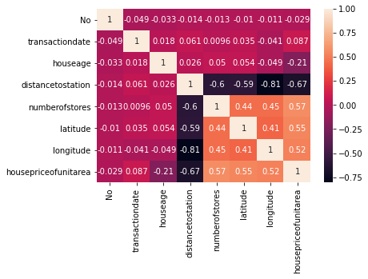

```python
import  seaborn as sns

sns.heatmap(HouseData.corr(),annot=True)
```

```python
HouseData.head()
```

|  | No | transactiondate | houseage | distancetostation | numberofstores | latitude | longitude | housepriceofunitarea |
| --- | --- | --- | --- | --- | --- | --- | --- | --- |
| 14 | 1 | 2012.917 | 32.0 | 84.87882 | 10 | 24.98298 | 121.54024 | 37.9 |
| 15 | 2 | 2012.917 | 19.5 | 306.59470 | 9 | 24.98034 | 121.53951 | 42.2 |
| 16 | 3 | 2013.583 | 13.3 | 561.98450 | 5 | 24.98746 | 121.54391 | 47.3 |
| 17 | 4 | 2013.500 | 13.3 | 561.98450 | 5 | 24.98746 | 121.54391 | 54.8 |
| 18 | 5 | 2012.833 | 5.0 | 390.56840 | 5 | 24.97937 | 121.54245 | 43.1 |

I split the data into two parts: input (data) and output (target, price). I want to try to split transactiondate into year and month, but as I understand from the data the transactiondate is saved as the numerical data instead of the date. Thus, I could not use that column and will drop it. Also, I want to scale my numerical values.

```python
price = HouseData["housepriceofunitarea"]
data = HouseData.drop(columns = ["housepriceofunitarea", "transactiondate"] , axis = 1)
```

Firstly, I want to try linear regression without any data preprocessing.

```python
from sklearn.linear_model import LinearRegression
lin_reg = LinearRegression()
lin_reg.fit(data, price)
lin_reg.score(data, price)
```

```
0.5724660229222989
```

```python
price = HouseData["housepriceofunitarea"]
dropped_data = data.drop(columns = ["No" , "houseage" , "distancetostation" ], axis = 1)
```

```python
from sklearn.linear_model import LinearRegression
lin_reg = LinearRegression()
lin_reg.fit(dropped_data , price)
lin_reg.score(dropped_data , price)
```

```
0.48095106332615767
```

The accuracy of the model decreased. I am curious about the relationship between the latitude and the price of the house. Actually, I dont want to include these features (latitude and longitude) to my training set, because these values vary in a very small range and I think that instead of the numerical value of the latitude and longitude, the name of the neighborhood that the house located in would be more useful.

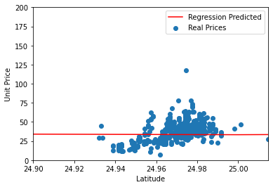

```python
predicted_data = lin_reg.predict(dropped_data)
fig = plt.figure()
plt.scatter(HouseData["latitude"],HouseData["housepriceofunitarea"])
plt.xlabel("Latitude")
plt.ylabel("Unit Price")
plt.ylim(0,200)
plt.xlim(24.9,25.01459)
plt.plot(predicted_data,'r')
plt.legend(['Regression Predicted','Real Prices'])
```

When I plotted the values, I saw a red line as the predicted value, but I believe that there should be more convenient line that fits that data.

Based my own experiences, the age of the house is an important feature for determining the price. Thus, I decided to add that feature to my training set.

```python
dropped_data2 = data.drop(columns = ["No" , "distancetostation"], axis = 1)
lin_reg = LinearRegression()
lin_reg.fit(dropped_data2 , price)
lin_reg.score(dropped_data2 , price)
```

```
0.5347208212325628
```

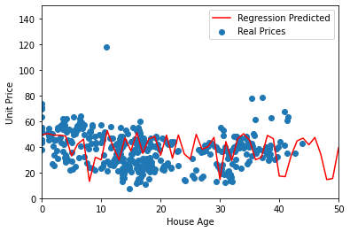

```python
predicted_data = lin_reg.predict(dropped_data2)
fig = plt.figure()
plt.scatter(HouseData["houseage"] , HouseData["housepriceofunitarea"])
plt.xlabel("House Age")
plt.ylabel("Unit Price")
plt.xlim(0,50)
plt.ylim(0,150)
plt.plot(predicted_data,'r')
plt.legend(['Regression Predicted','Real Prices'])
```

When I plotted the data, the line that regression predicted is not smooth as I expected. Maybe, it overfits the data but I dont know how can I understand this explicitly.

After that, as I said before, I dont want to longitude and latitude in my training set. Thus, for observing what will happen, I am going to drop that features. In addition to this, I will scale the numerical values in my data set. As I believed from the beginning, the distance to the station, number of the stores around the house, and the number of the house are the most important features for determining the selling price of the house. Thus, I will use that features by considering my experiences and ignoring the heat map.

```python
dropped_data3 = data.drop(columns = ["No" , "longitude" , "latitude" ], axis = 1)
from sklearn.preprocessing import StandardScaler
scaler = StandardScaler()
scaler.fit(dropped_data3)
data_scaled = scaler.transform(dropped_data3)
lin_reg = LinearRegression()
lin_reg.fit(data_scaled , price)
lin_reg.score(data_scaled , price)
```

```
0.5410632980005723
```

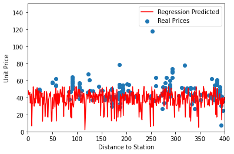

```python
predicted_data = lin_reg.predict(data_scaled)
fig = plt.figure()
plt.scatter(HouseData["distancetostation"] , HouseData["housepriceofunitarea"])
plt.xlabel("Distance to Station")
plt.ylabel("Unit Price")
plt.xlim(0,400)
plt.ylim(0,150)
plt.plot(predicted_data,'r')
plt.legend(['Regression Predicted','Real Prices'])
```

There is a weird visualization of the real and predicted data. Actually, I dont know how can I interpret it but it seems terrible.

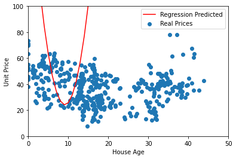

```python
predicted_data = lin_reg.predict(data_scaled)
fig = plt.figure()
plt.scatter(HouseData["houseage"] , HouseData["housepriceofunitarea"])
plt.xlabel("House Age")
plt.ylabel("Unit Price")
plt.xlim(0,50)
plt.ylim(0,100)
plt.plot(PredictedPrice,'r')
plt.legend(['Regression Predicted','Real Prices'])
```

The accuracy values are 0.57 , 0.48 , 0.53 , and 0.54 .

As a result, the highest accuracy value that I can obtain is the first prediction which I did not any data preprocessing.

I am going to try polynomial regression by hoping that I can obtain better predictions and higher accuracy.

```python
from sklearn.preprocessing import PolynomialFeatures
n_poly_degree = 2
poly = PolynomialFeatures(n_poly_degree)
data_transformed = poly.fit_transform(data_scaled)
lin_reg = LinearRegression()
lin_reg.fit(data_transformed , price)
lin_reg.score(data_transformed , price)
```

```
0.6205008288563045
```

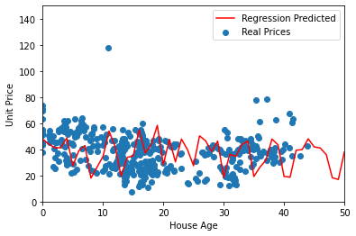

```python
predicted_data = lin_reg.predict(data_transformed)
fig = plt.figure()
plt.scatter(HouseData["houseage"] , HouseData["housepriceofunitarea"])
plt.xlabel("House Age")
plt.ylabel("Unit Price")
plt.xlim(0,50)
plt.ylim(0,150)
plt.plot(predicted_data,'r')
plt.legend(['Regression Predicted','Real Prices'])
```

The accuracy increased and the graph is slightly different than the other graphs that I had by using simple linear regression.

After that, I try a lot of different values for the degree of the polynomial because I dont know the optimal value for it. Accuracy values increased and get stuck around 12. But, I have already had a high accuracy which is around %98.

```python
from sklearn.preprocessing import PolynomialFeatures
n_poly_degree = 12
poly = PolynomialFeatures(n_poly_degree)
data_transformed = poly.fit_transform(data_scaled)
lin_reg = LinearRegression()
lin_reg.fit(data_transformed , price)
lin_reg.score(data_transformed , price)
```

```
0.9871607842066893
```

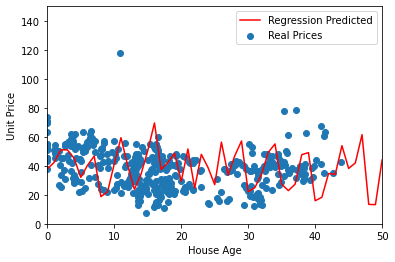

```python
predicted_data = lin_reg.predict(data_transformed)
fig = plt.figure()
plt.scatter(HouseData["houseage"] , HouseData["housepriceofunitarea"])
plt.xlabel("House Age")
plt.ylabel("Unit Price")
plt.xlim(0,50)
plt.ylim(0,150)
plt.plot(predicted_data,'r')
plt.legend(['Regression Predicted','Real Prices'])
```

Although I had a very high accuracy, not having a great line that fits a data well does not satisfy me. Most probably, my model is overfitting the data. So, I am going to try ridge regression so that I can use regularization.

```python
from sklearn.linear_model import Ridge
ridgereg = Ridge(alpha=0.05, normalize=True)
ridgereg.fit(dropped_data3, price)
y_pred = ridgereg.predict(dropped_data3)
ridgereg.score(dropped_data3, price)
```

```
0.5404071088190062
```

My accuracy is decreased again, but I dont know why.

# Feedback

We appreciate feedbacks from you to make the exercise better for future generations.

1) What do you find most useful in this document?

2) Is there any part that was not clear to you?

3) How do you rank your coding and regression skills before the task and how difficult was to follow this document?

4) Any other suggestions to make it more fun?

1. I think the part that I compare the models until 10th and 14th data is the most useful part in terms of observing the differences between simple linear regression and polynomial regression.
2. Yes, the part (reg.score, out[177]) is not clear for me. Do you expect the accuracy for the 177th example in the data set?
3. Understanding your code and coding again are not difficult for me, but there are some parts that I cannot code by myself and with my knowledge although I understand your code. It is beacuse of the my lack of experience in coding. Also, my regression knowledge is enough to follow the notebook.
4. Making a short presentation to someone (just a person from the working group) would be useful and fun. Also, we can know each other with this way.